# Coursera Regression Models: MPG Analysis

Saturday, May 23, 2015

### Executive Summary

*Motor Trend* magazine is interested in exploring the relationship between a set of variables and miles per gallon (MPG) (outcome). More specifically, they are interested in whether automatic or manual transmission cars get better gas mileage and would like to see the differences quantified. Using regression analysis on the mtcars dataset, we can show that on average cars with manaual transmissions get better gas mileage than automatic (24.4 vs 17.1), but that there are more important variables that impact mpg than just the type of transmission, such as vehicle weight, size of engine, etc…

### Exploratory Data Analysis

First we take a look at all of the different measurements and factors vs. MPG to get an idea of which variables could be influential on the mpg. [^1]

In order to better understand the variables that most influence mpg, the next step was to look at a linear regression including all variables.

```r
fit1=lm(mpg ~ ., data=mtcars)
summary(fit1)$coef
```

```
##                Estimate  Std. Error    t value   Pr(>|t|)
## (Intercept) 12.30337416 18.71788443  0.6573058 0.51812440
## cyl         -0.11144048  1.04502336 -0.1066392 0.91608738
## disp         0.01333524  0.01785750  0.7467585 0.46348865
## hp          -0.02148212  0.02176858 -0.9868407 0.33495531
## drat         0.78711097  1.63537307  0.4813036 0.63527790
## wt          -3.71530393  1.89441430 -1.9611887 0.06325215
## qsec         0.82104075  0.73084480  1.1234133 0.27394127
## vs           0.31776281  2.10450861  0.1509915 0.88142347
## am           2.52022689  2.05665055  1.2254035 0.23398971
## gear         0.65541302  1.49325996  0.4389142 0.66520643
## carb        -0.19941925  0.82875250 -0.2406258 0.81217871
```

```r
fit1R2=summary(fit1)$r.squared
```

```r
fit2=lm(mtcars$mpg ~ mtcars$am)
summary(fit2)$coef
```

```
##              Estimate Std. Error   t value     Pr(>|t|)
## (Intercept) 17.147368   1.124603 15.247492 1.133983e-15
## mtcars$am    7.244939   1.764422  4.106127 2.850207e-04
```

```r
fit2R2=summary(fit2)$r.squared

fit3=lm(mtcars$mpg ~ mtcars$am+mtcars$wt)
summary(fit3)$coef
```

```
##                Estimate Std. Error     t value     Pr(>|t|)
## (Intercept) 37.32155131  3.0546385 12.21799285 5.843477e-13
## mtcars$am   -0.02361522  1.5456453 -0.01527855 9.879146e-01
## mtcars$wt   -5.35281145  0.7882438 -6.79080719 1.867415e-07
```

```r
fit3R2=summary(fit3)$r.squared

fit4=lm(mpg ~ am+ wt+cyl, data=mtcars)
summary(fit4)$coef
```

```
##               Estimate Std. Error    t value     Pr(>|t|)
## (Intercept) 39.4179334  2.6414573 14.9227979 7.424998e-15
## am           0.1764932  1.3044515  0.1353007 8.933421e-01
## wt          -3.1251422  0.9108827 -3.4308942 1.885894e-03
## cyl         -1.5102457  0.4222792 -3.5764148 1.291605e-03
```

```r
fit4R2=summary(fit4)$r.squared

fit5=lm(mpg ~ wt+cyl, data=mtcars)
summary(fit5)$coef
```

```
##              Estimate Std. Error   t value     Pr(>|t|)
## (Intercept) 39.686261  1.7149840 23.140893 3.043182e-20
## wt          -3.190972  0.7569065 -4.215808 2.220200e-04
## cyl         -1.507795  0.4146883 -3.635972 1.064282e-03
```

```r
fit5R2=summary(fit5)$r.squared

fit6=lm(mpg ~ wt+cyl+disp, data=mtcars)
summary(fit6)$coef
```

```
##                 Estimate Std. Error    t value     Pr(>|t|)
## (Intercept) 41.107677641 2.84242604 14.4621802 1.620381e-14
## wt          -3.635677016 1.04013753 -3.4953811 1.595519e-03
## cyl         -1.784943519 0.60711048 -2.9400638 6.511676e-03
## disp         0.007472925 0.01184472  0.6309079 5.332173e-01
```

```r
fit6R2=summary(fit6)$r.squared
```

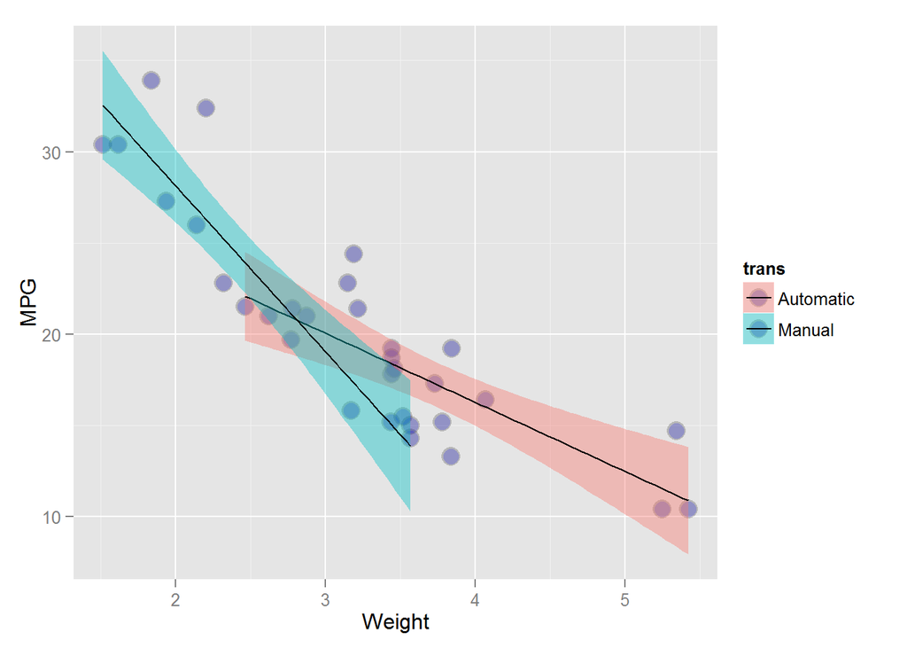

### Appendix

[^1]: Exploratory Plots. We could have used a pairs plot, but this showed all combinations of variables. Since we are only interested in MPG, I limited the plots to only MPG as the Y variable.

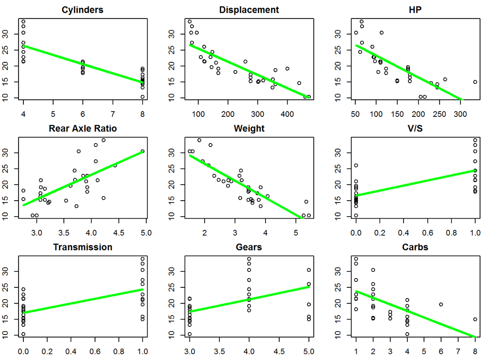